# Canadian Housing Starts

StatsCan regularly collects information on new housing construction in Canada, something that has become ever more important as housing demand has increased and the population of Canada's largest cities has greatly increased. We'll grab the data on various categories of housing in Canada and also data on Canadian GDP as well, something that should correlate with housing starts.

```python
import pandas as pd
import numpy as np
from scipy import stats
from sklearn.linear_model import LinearRegression
from sklearn.model_selection import train_test_split, KFold, cross_val_score
import altair as alt
alt.renderers.enable('notebook')
```

```
RendererRegistry.enable('notebook')
```

```python
gdp = pd.read_csv('./gdp 97-2018.csv')
```

```python
housing = pd.read_csv('./housing starts 88-18.csv')
```

```python
gdp['date'] = gdp['date'].astype(str)
housing['date'] = housing['date'].astype(str)
```

```python
df = gdp.merge(housing, on='date', how='left')
```

```python
df['gdp'] = df['gdp'].str.replace(',', '')
df['total'] = df['total'].str.replace(',', '')
df['single_detached'] = df['single_detached'].str.replace(',', '')
df['semi_detached'] = df['semi_detached'].str.replace(',', '')
df['row_units'] = df['row_units'].str.replace(',', '')
df['apartment_other'] = df['apartment_other'].str.replace(',', '')
```

```python
df['gdp'] = df['gdp'].astype(int)
df['total'] = df['total'].astype(int)
df['single_detached'] = df['single_detached'].astype(int)
df['semi_detached'] = df['semi_detached'].astype(int)
df['row_units'] = df['row_units'].astype(int)
df['apartment_other'] = df['apartment_other'].astype(int)
```

```python
df.head()
```

|  | date | gdp | total | single_detached | semi_detached | row_units | apartment_other |
| --- | --- | --- | --- | --- | --- | --- | --- |
| 0 | Jan-97 | 1047885 | 5769 | 3049 | 438 | 605 | 1677 |
| 1 | Feb-97 | 1054493 | 6290 | 3597 | 498 | 832 | 1363 |
| 2 | Mar-97 | 1054384 | 6663 | 3978 | 641 | 614 | 1430 |
| 3 | Apr-97 | 1061535 | 10244 | 6024 | 897 | 1262 | 2061 |
| 4 | May-97 | 1065312 | 12638 | 7652 | 1203 | 1681 | 2102 |

The first interesting observation we can get from the data is the cyclical nature of housing construction in Canada due to our harsh winters.

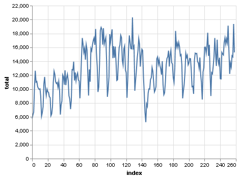

```python
alt.Chart(df.reset_index()).mark_line().encode(
    x='index',
    y='total'
)
```

Another clear trend is the the changing composition of housing starts, we can graph the the percentage of housing starts represented by each category where we can see that the construction of apartment units has greatly surpassed that of single-detached homes. This is likely indicative of the development of Canada's largest cities increasing the demand for high-density housing.

```python
df['percent_apart'] = df['apartment_other']/df['total']
df['percent_detach'] = df['single_detached']/df['total']
df['percent_semi'] = df['semi_detached']/df['total']
df['percent_row'] = df['row_units']/df['total']
```

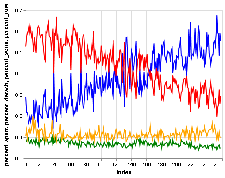

```python
base = alt.Chart(df.reset_index()).encode(x='index')

alt.layer(
    base.mark_line(color='blue').encode(y='percent_apart'),
    base.mark_line(color='red').encode(y='percent_detach'),
    base.mark_line(color='green').encode(y='percent_semi'),
    base.mark_line(color='orange').encode(y='percent_row')
)
```

Also observable in our graph of total housing starts is the effect of the Great Recession which greatly supressed housing housing construction in its wake. We can look at the total housing starts for each year from 2007-2010 to see its effect

```python
total_2007 = df['total'].iloc[120:132].sum()
total_2008 = df['total'].iloc[132:144].sum()
total_2009 = df['total'].iloc[144:156].sum()
total_2010 = df['total'].iloc[156:168].sum()
```

```python
print('2007:', total_2007)
print('2008:', total_2008)
print('2009:', total_2009)
print('2010:', total_2010)
```

```
2007: 176407
2008: 168212
2009: 116400
2010: 149663
```

Clearly the economic turmoil and more restrictive lending conditions following during the recession were a noticeable setback for the Canadian housing industry's apparently constant upward trend. To further investigate the the upward trend of Canada's housing construction we can investigate the relationship between housing construction and Canada's GDP.

Our first step is to split our data and attempt to generate regressions to see how well we can predict against our known set.

```python
y = df['total']
X = df['gdp']
```

```python
X_train, X_test, y_train, y_test = train_test_split(X, y, random_state=42, test_size=0.2)
lr = LinearRegression()
```

```python
kf = KFold(n_splits=5, random_state=42, shuffle=True)
```

```python
cross_val_score(lr, X_train.values.reshape(-1,1), y_train, cv=kf)
```

```
array([0.219518  , 0.12541055, 0.1706521 , 0.16290158, 0.23302813])
```

```python
lr.fit(X_train.values.reshape(-1,1), y_train)
```

```
LinearRegression(copy_X=True, fit_intercept=True, n_jobs=1, normalize=False)
```

```python
lr.score(X_test.values.reshape(-1,1), y_test)
```

```
0.20301515790980784
```

It appears that GDP alone is a poor predictor of total housing starts, its ability to predict housing starts may also be influenced by it having a lagging effect on housing starts rather than an effect in the same month.

It is also likely that we need to add additional features such as population, the Bank of Canada's prime rate, and the general availability of credit to consumers.

Going forward it would also be useful to generate seasonal or quarterly dummy variables and use them to quantify the effect winter has on housing construction.

I'll probably come back to this if I can source accurate date on these factors and create a more complete model.